# Paper: Do Concepts Matter? [Script]

Felipe Rocha, Rodrigo Albuquerque, Marcelo de Almeida Medeiros

## Info

This document aims to show all commands used to generate the results and figures exhibited at the paper entitled: “Do Concepts Matter? Latin America and South America in the Discourse of Brazilian Foreign Policymakers”

## Packages

```r
require(tidyverse)
```

## Database

As explained at the methodological section of the paper, the database [or Corpus] was provided by Itamaraty, and it is available on its [official website](http://www.itamaraty.gov.br/pt-BR/resenha-de-politica-exterior-do-brasil). However, we had to convert and change some features on some documents, as explained in the paper. This is exactly the reason why we created a folder called “corpus.rar” in which all data are also available. The number of speeches is an approximation based on the manual counting of the original summary as presented in the first pages of each document. The number of frequencies to Latin America and to South America were made through queries based on the expressions showed at the methodological appendix. For more information, please consult the codebook and other files available on this replication folder. Having said that, here follows the database:

```r
database <- read.csv("dataframe_paper_do_concepts_matter.csv")
database
```

```
##    year resenha.pe latin.america south.america latin.minus.south president
## 1  1995         77           113            84                29         1
## 2  1996        140           170           107                63         1
## 3  1997         48            59            40                19         1
## 4  1998         64            42            21                21         1
## 5  1999         54            73            62                11         2
## 6  2000        245           197           458              -261         2
## 7  2001        264           158           134                24         2
## 8  2002        337           148           142                 6         2
## 9  2003        276           129           458              -329         3
## 10 2004        575           200           424              -224         3
## 11 2005        565           201           897              -696         3
## 12 2006        640           233           667              -434         3
## 13 2007        707           301           415              -114         4
## 14 2008        361           161           226               -65         4
```

[output cut: 27 more lines]

## Graph 01. Frequency of discourses per year

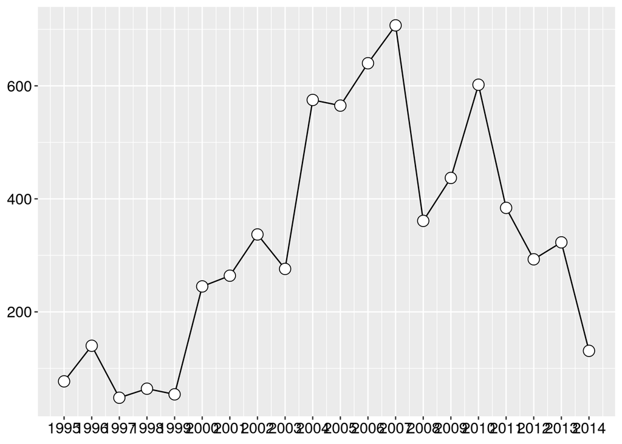

```r
ggplot(database, aes(x=year, y=resenha.pe)) + geom_line() + geom_point(shape=21, fill="white", size=4) + scale_x_continuous(breaks = database$year) + theme(axis.title.x = element_blank(), axis.title.y = element_blank(), axis.text.x = element_text(colour = "black", size = rel(1.4)), axis.text.y = element_text(colour = "black", size=rel(1.4)))
```

## Graph 02. Frequency of use of the terms Latin America and South America per year

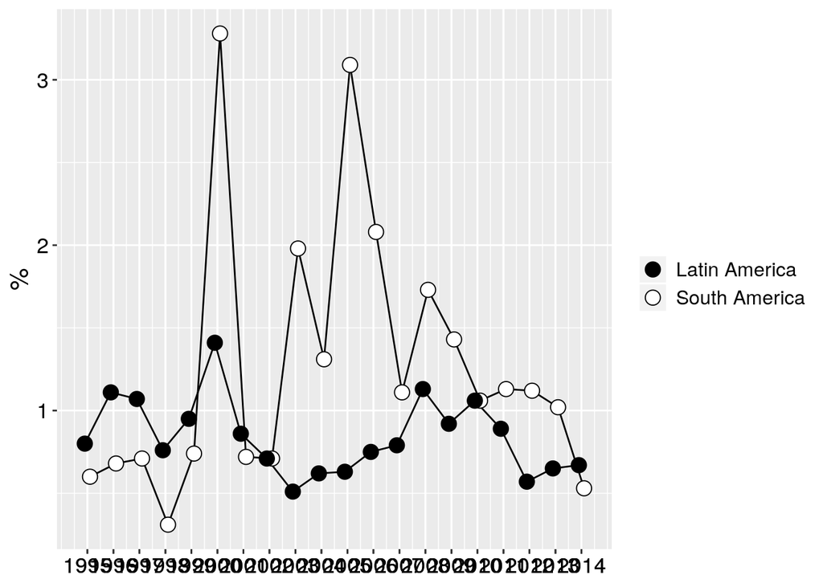

```r
g2 <- database %>% select(year, perc.latin.america, perc.south.america) %>% gather(key = conceitos, value = valores, -year)

ggplot(g2, aes(x=year, y=valores, fill=conceitos)) + geom_line(position = position_dodge(0.4)) + geom_point(shape=21, size=4, position = position_dodge(0.4)) +scale_fill_manual(values = c("black", "white"), label=c("Latin America", "South America")) + guides(fill=guide_legend(title = NULL)) + theme(axis.title.x = element_blank(), axis.text.x = element_text(colour = "black", size = rel(1.5)), axis.text.y = element_text(colour = "black", size = rel(1.5)), legend.text = element_text(size=12), axis.title.y = element_text(size = rel(1.4))) + scale_x_continuous(breaks = g2$year) + ylab("%")
```

## Graph 03. Annual Dominance

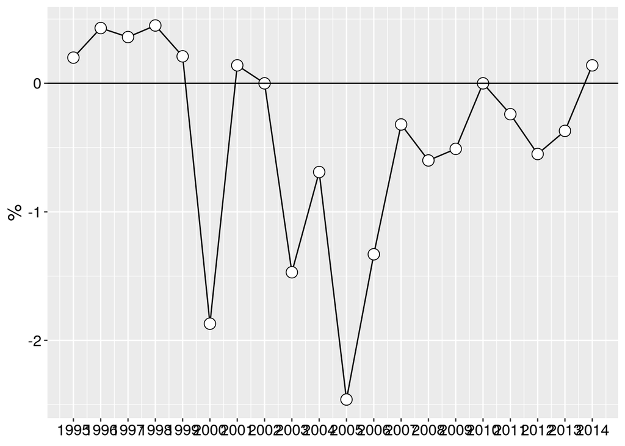

```r
ggplot(database, aes(x=year, y=perc.latin.minus.south)) + geom_line() + geom_point(shape=21, size=4, fill="white") + scale_x_continuous(breaks = database$year) + geom_hline(yintercept = 0) + theme(axis.title.x = element_blank(), axis.text.x = element_text(colour = "black", size = rel(1.4)), axis.text.y = element_text(colour = "black", size = rel(1.4)), axis.title.y = element_text(size=rel(1.4))) + ylab("%")
```

## Graph 04. Latin America and South America by presidential terms (mean)

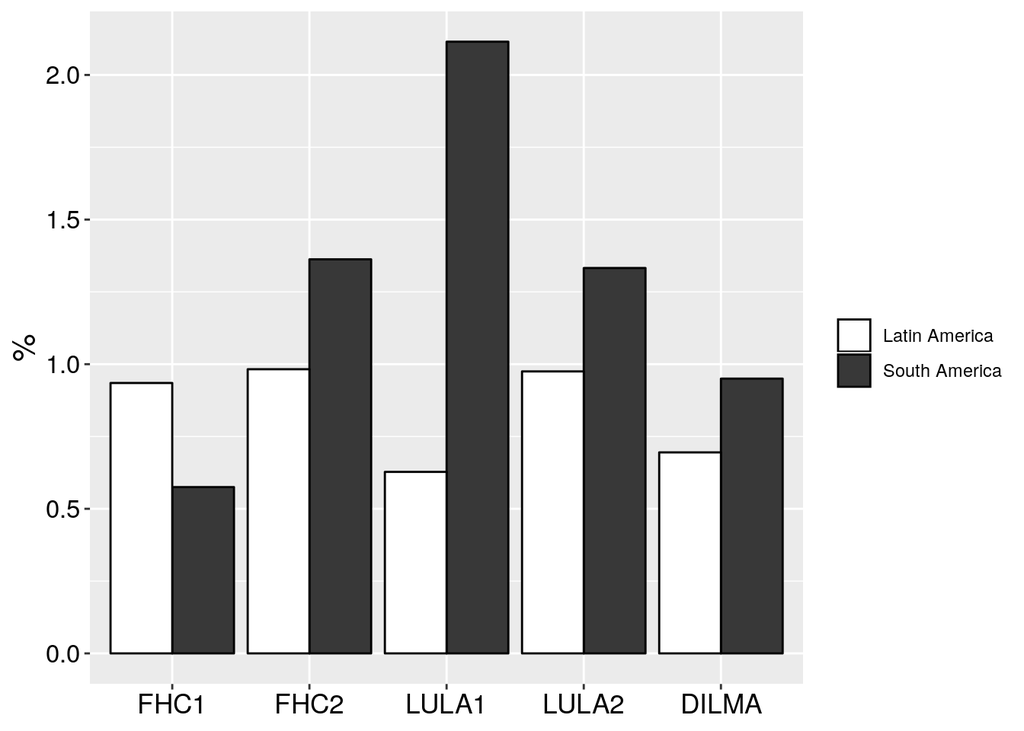

```r
g4 <- database %>% select(president, perc.latin.america, perc.south.america)

g4$president <- factor(g4$president, levels = c(1,2,3,4,5), labels = c("FHC1", "FHC2", "LULA1", "LULA2", "DILMA"))

g4 <- gather(g4, key = "conceitos", value = "valores", -president)

ggplot(g4, aes(x=president, y=valores, fill=conceitos)) + geom_bar(position="dodge", stat="summary", fun.y="mean", colour="black") +scale_fill_manual(values = c("white", "grey22"), label=c("Latin America", "South America")) + theme(axis.title.x = element_blank(), axis.text.x = element_text(colour = "black", size=rel(1.5)), axis.title.y = element_text(size = rel(1.4), colour = "black"), axis.text.y = element_text(size = rel(1.4), colour = "black")) + ylab("%") + guides(fill=guide_legend(title = NULL))
```

## Graph 05. Conceptual dominance by presidential terms (mean)

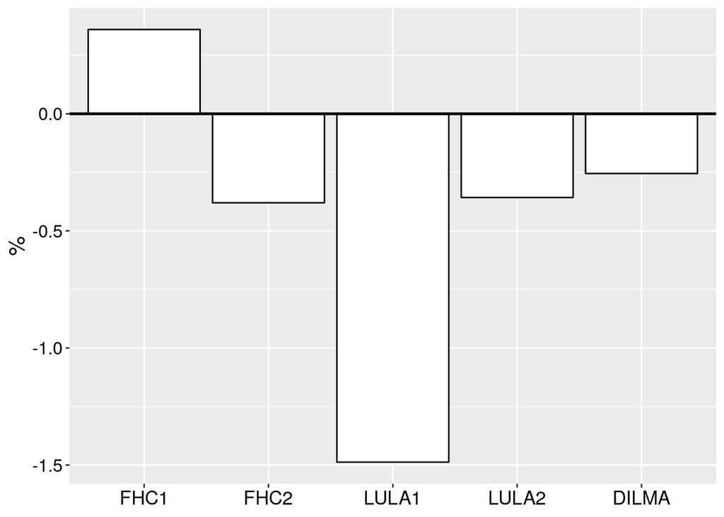

```r
g5 <- database %>% select(president, perc.latin.minus.south)
g5$president <- factor(g5$president, levels = c(1,2,3,4,5), labels = c("FHC1", "FHC2", "LULA1", "LULA2", "DILMA"))


ggplot(g5, aes(x=president, y=perc.latin.minus.south)) + geom_bar(position="dodge", stat="summary", fun.y="mean", fill="white", colour="black")  + theme(axis.title.x = element_blank(), axis.text.x = element_text(colour = "black", size=rel(1.5)), axis.title.y = element_text(size = rel(1.4), colour = "black"), axis.text.y = element_text(size = rel(1.4), colour = "black")) + ylab("%") + guides(fill=guide_legend(title = NULL)) + geom_hline(yintercept = 0, colour="black", size=.9)
```